# Leading-Edge Technology in Education: Its impact on Students’ Academic Behavior

Biruk Kebede Metaferia

January 8, 2018

## Executive Summary

#### About the Dataset

The dataset (“Students’ Academic Performance Dataset”) used in this project was accessed from kaggle public dataset (https://www.kaggle.com/aljarah/xAPI-Edu-Data/data). It was found in csv format (xAPI-Edu-Data.csv) with its codebook. It consists of 480 participants and 16 variables. As clearly mentioned in the introduction part of the codebook the variables in the dataset are classified into three major categories: (1) Demographic features such as gender and nationality; (2) Academic background features such as educational stage, grade Level and section; (3) Behavioral features such as raised hand on class, opening resources, answering survey by parents, and parents’ school satisfaction. The dataset has no missing value from the very beginning. Generally, the dataset consists of an educational information which is collected from learning management system (LMS), that has been designed to facilitate learning through applying leading-edge technology in education. The system provides users with a synchronous access to educational resources from any device with Internet connection.The data is collected using a learner activity tracker tool, which is a component of the training and learning architecture that enables to monitor students learning progress and their actions like reading an article or watching a training video. More details about the dataset including its codebook is variable at https://www.kaggle.com/aljarah/xAPI-Edu-Data

Load the important packages

```r
library(tidyverse)
library(broom)
library(psych)
library(stargazer)
library(car)
```

Import the dataset

```r
given_dataset<- read_csv(file="/Users/biruk/Dropbox/Final_R_Project/xAPI-Edu-Data.csv")
```

#### Exploratory Analysis

##### Study the variables in the dataset

Explore the nature of the variables in the dataset using summary function

```r
summary(given_dataset)
```

```
##     gender          NationalITy        PlaceofBirth
##  Length:480         Length:480         Length:480
##  Class :character   Class :character   Class :character
##  Mode  :character   Mode  :character   Mode  :character
##
##
##
##    StageID            GradeID           SectionID
##  Length:480         Length:480         Length:480
##  Class :character   Class :character   Class :character
##  Mode  :character   Mode  :character   Mode  :character
##
##
##
##     Topic             Semester           Relation          raisedhands
##  Length:480         Length:480         Length:480         Min.   :  0.00
##  Class :character   Class :character   Class :character   1st Qu.: 15.75
##  Mode  :character   Mode  :character   Mode  :character   Median : 50.00
##                                                           Mean   : 46.77
##                                                           3rd Qu.: 75.00
##                                                           Max.   :100.00
##  VisITedResources AnnouncementsView   Discussion    ParentAnsweringSurvey
##  Min.   : 0.0     Min.   : 0.00     Min.   : 1.00   Length:480
##  1st Qu.:20.0     1st Qu.:14.00     1st Qu.:20.00   Class :character
##  Median :65.0     Median :33.00     Median :39.00   Mode  :character
##  Mean   :54.8     Mean   :37.92     Mean   :43.28
##  3rd Qu.:84.0     3rd Qu.:58.00     3rd Qu.:70.00
##  Max.   :99.0     Max.   :98.00     Max.   :99.00
##  ParentschoolSatisfaction StudentAbsenceDays    Class
##  Length:480               Length:480         Length:480
##  Class :character         Class :character   Class :character
##  Mode  :character         Mode  :character   Mode  :character
##
##
##
```

Study missing values in the dataset

```r
sapply(given_dataset,function(x) sum(is.na(x)))
```

```
##                   gender              NationalITy             PlaceofBirth
##                        0                        0                        0
##                  StageID                  GradeID                SectionID
##                        0                        0                        0
##                    Topic                 Semester                 Relation
##                        0                        0                        0
##              raisedhands         VisITedResources        AnnouncementsView
##                        0                        0                        0
##               Discussion    ParentAnsweringSurvey ParentschoolSatisfaction
##                        0                        0                        0
##       StudentAbsenceDays                    Class
##                        0                        0
```

No variable in the dataset has missing value

Exclude variables not to be used in this project

```r
performance_data<-given_dataset %>%
 select(-PlaceofBirth, -StageID, -GradeID, -SectionID, -Semester, -ParentAnsweringSurvey, -StudentAbsenceDays)
```

Explor the possible scores for non-continous variables

```r
performance_data %>% distinct(gender)
```

```
## # A tibble: 2 x 1
##   gender
##    <chr>
## 1      M
## 2      F
```

```r
performance_data %>% distinct(Topic)
```

```
## # A tibble: 12 x 1
##        Topic
##        <chr>
##  1        IT
##  2      Math
##  3    Arabic
##  4   Science
##  5   English
##  6     Quran
##  7   Spanish
##  8    French
##  9   History
## 10   Biology
## 11 Chemistry
## 12   Geology
```

```r
performance_data %>% distinct(Relation)
```

```
## # A tibble: 2 x 1
##   Relation
##      <chr>
## 1   Father
## 2      Mum
```

```r
performance_data %>% distinct(ParentschoolSatisfaction)
```

```
## # A tibble: 2 x 1
##   ParentschoolSatisfaction
##                      <chr>
## 1                     Good
## 2                      Bad
```

```r
performance_data %>% distinct(Class)
```

```
## # A tibble: 3 x 1
##   Class
##   <chr>
## 1     M
## 2     L
## 3     H
```

```r
performance_data %>% distinct(NationalITy)
```

```
## # A tibble: 14 x 1
##    NationalITy
##          <chr>
##  1          KW
##  2     lebanon
##  3       Egypt
##  4 SaudiArabia
##  5         USA
##  6      Jordan
##  7    venzuela
##  8        Iran
##  9       Tunis
## 10     Morocco
## 11       Syria
## 12   Palestine
## 13        Iraq
## 14       Lybia
```

Inform the nature of the qualitative variables to R

```r
subject <-factor(performance_data$Topic, levels = c("English", "Spanish", "French", "Arabic", "IT", "Math", "Chemistry", "Biology", "Science", "History", "Quran", "Geology"))
resp_parent <- factor(performance_data$Relation, levels = c("Mum", "Father"))
Parent_Sats <- ordered(performance_data$ParentschoolSatisfaction, levels = c("Bad", "Good"))
final_grade <- ordered(performance_data$Class, levels = c("L", "M", "H"))
sex <- factor(performance_data$gender, levels = c("F", "M"))
citizenship <- factor(performance_data$NationalITy,levels = c("KW", "lebanon", "Egypt", "SaudiArabia", "USA", "Jordan", "venzuela", "Iran", "Tunis", "Morocco", "Syria", "Palestine", "Iraq", "Lybia"))
```

Transformed the dataset so that string variables will be changed to numberc form

```r
stud_performance_data<-performance_data %>%
  mutate (subject = as.integer(factor(Topic, levels = c("English", "Spanish", "French", "Arabic", "IT", "Math", "Chemistry", "Biology", "Science", "History", "Quran", "Geology"))),
          resp_parent = as.integer(factor(Relation, levels = c("Mum", "Father"))),
          Parent_Sats = as.integer(factor(ParentschoolSatisfaction, levels = c("Bad", "Good"))),
          final_grade = as.integer(factor(Class, levels = c("L", "M", "H"))),
          citizenship = as.integer(factor(NationalITy, levels = c("KW", "lebanon", "Egypt", "SaudiArabia", "USA", "Jordan", "venzuela", "Iran", "Tunis", "Morocco", "Syria", "Palestine", "Iraq", "Lybia"))),
          sex = as.integer(factor(gender, levels = c("F", "M")))) %>%
           as_tibble()
```

*Study outliers*

Explore outliers of the continous variables using boxplots and boxplot statistics functions

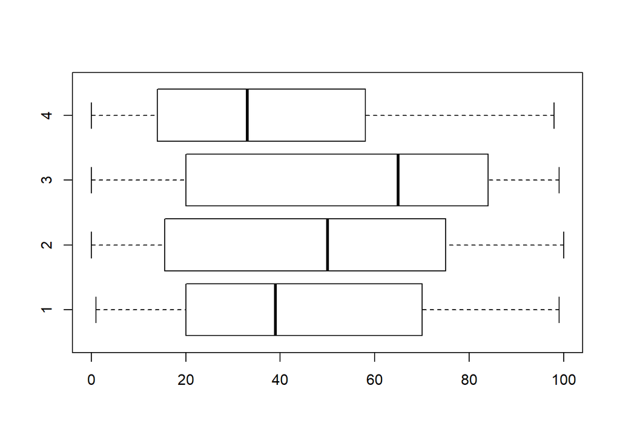

```r
boxplot(stud_performance_data$Discussion, stud_performance_data$raisedhands, stud_performance_data$VisITedResources, stud_performance_data$AnnouncementsView, horizontal=TRUE)
```

As can be clearly seen from the boxplots above there is no datapoint under lower limit and above upper limit in all of the four box plots. So, there is no outliers in all of the four variables.

Besides the boxplots, boxplot statistics can be used to also used to check outliers. For instance, the boxplot.stats function confirmed that there is no outliers in “discussion”

```r
boxplot.stats(stud_performance_data$Discussion)
```

```
## $stats
## [1]  1 20 39 70 99
##
## $n
## [1] 480
##
## $conf
## [1] 35.39416 42.60584
##
## $out
## integer(0)
```

##### Check for normality of quantitative variables in the dataset

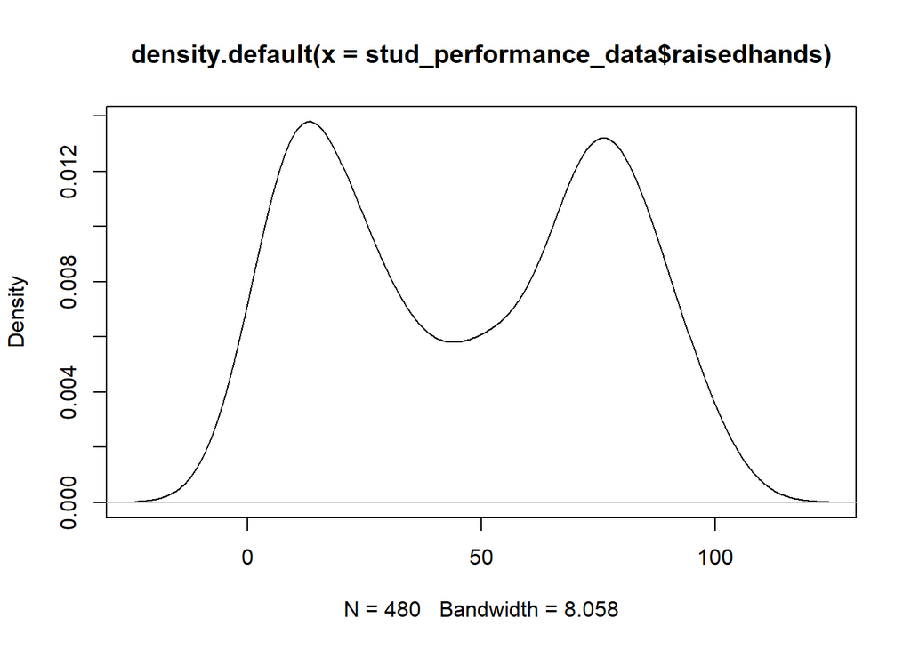

```r
plot (density(stud_performance_data$raisedhands))
```

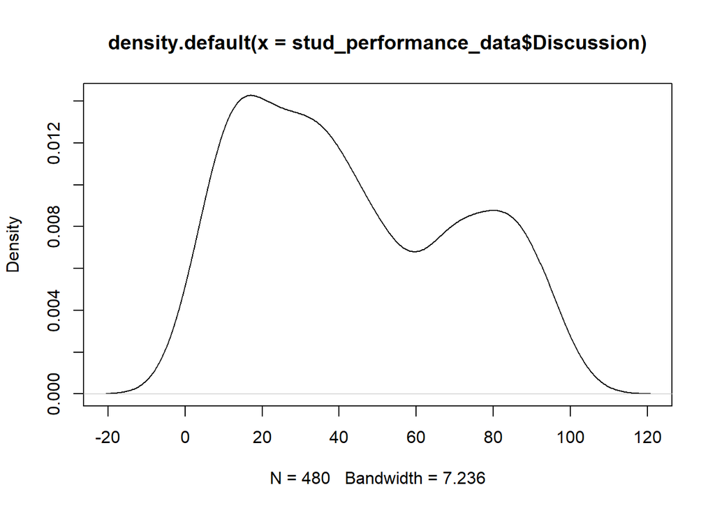

```r
plot(density(stud_performance_data$Discussion))
```

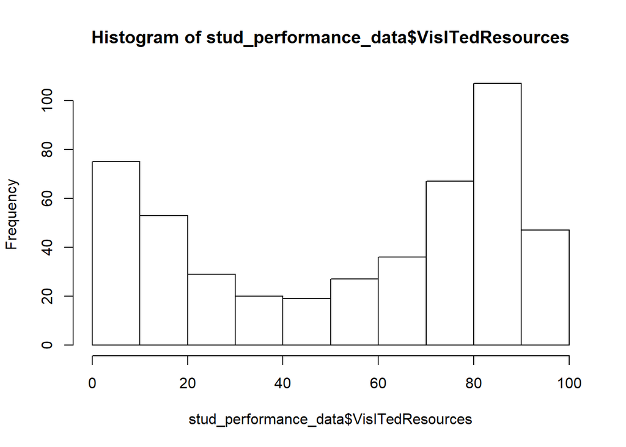

```r
hist(stud_performance_data$VisITedResources)
```

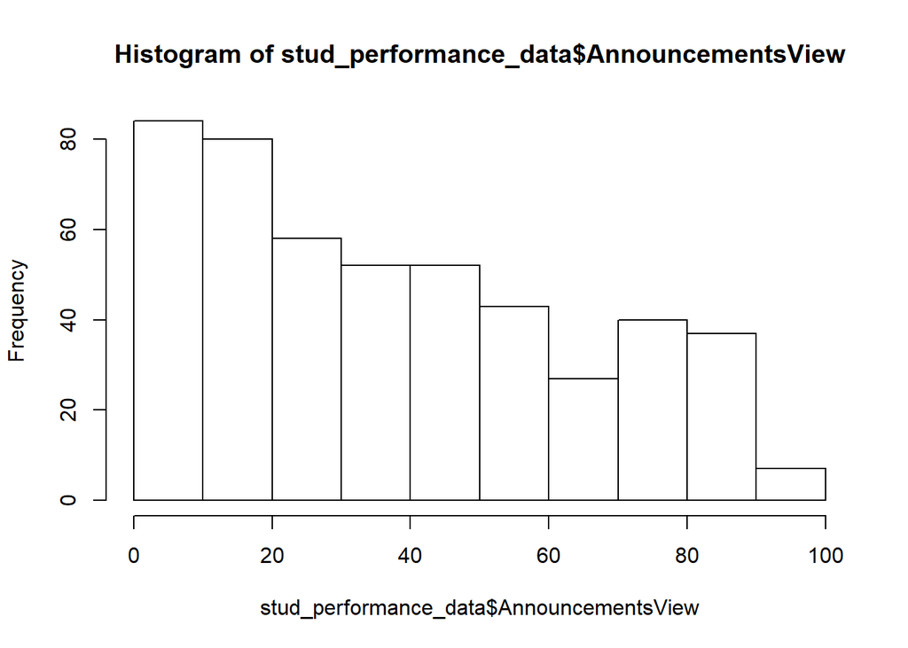

```r
hist(stud_performance_data$AnnouncementsView)
```

As can be seen from the plots above, the distribution of variables “raisedhands”, “Discussion”, “VisITedResources” and “AnnouncementsView” are not normal.

#### Visualization of the variables in the dataset

The composition of student participants in terms of the Subjects/courses can be indicated using pie plot.

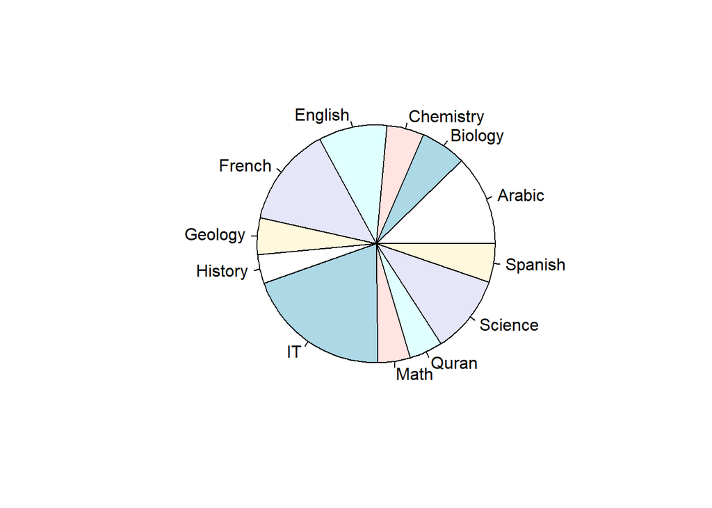

```r
pie(table(stud_performance_data$Topic))
```

The composition of student participants in terms of their citizenship can be communicated using bar plot

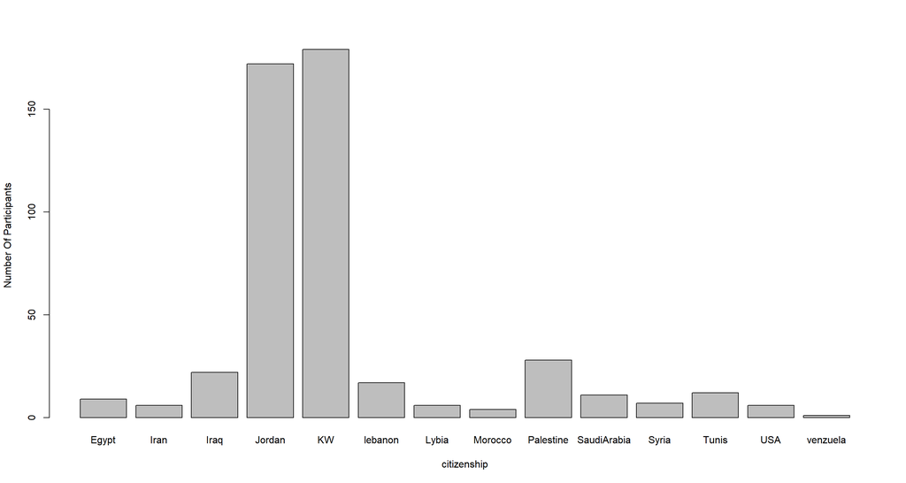

```r
barplot(table(stud_performance_data$NationalITy), xlab = 'citizenship', ylab = 'Number Of Participants')
```

### Hypotheses Testing

Test for association

*Is there association between students’ responsible parent and their satisfaction?*

```r
table(resp_parent, Parent_Sats)
```

```
##            Parent_Sats
## resp_parent Bad Good
##      Mum     44  153
##      Father 144  139
```

```r
chisq.test(table(resp_parent, Parent_Sats))
```

```
##
##  Pearson's Chi-squared test with Yates' continuity correction
##
## data:  table(resp_parent, Parent_Sats)
## X-squared = 38.541, df = 1, p-value = 5.363e-10
```

The chi-squared test result indicated that there is a satatistically significant association between students’ responsible parent for students education and their satisfaction (??2 (1, N = 480) = 38.541, p < .0001).

plot the result

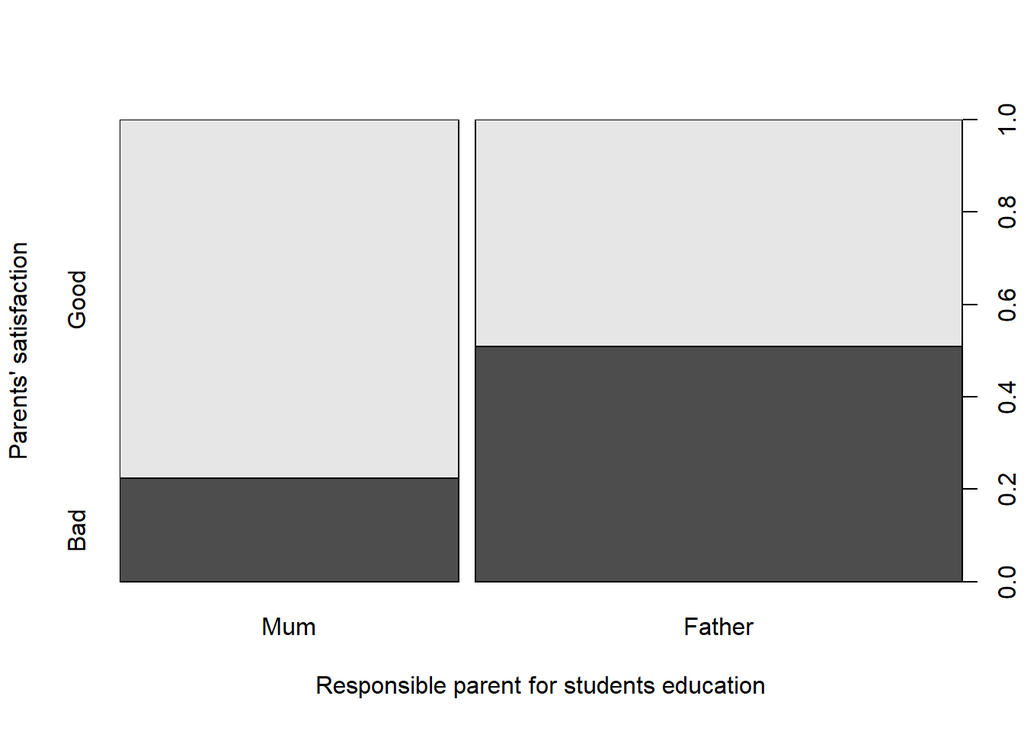

```r
plot(resp_parent, Parent_Sats, ylab = "Parents' satisfaction", xlab = "Responsible parent for students education")
```

The plot communicates that larger proportion of participants in mothers group have good satisfaction than fathers group

*Is there association between parents’ satisfaction and their children’s final grade score?*

```r
table(Parent_Sats, final_grade)
```

```
##            final_grade
## Parent_Sats   L   M   H
##        Bad   84  80  24
##        Good  43 131 118
```

```r
chisq.test(table(Parent_Sats, final_grade))
```

```
##
##  Pearson's Chi-squared test
##
## data:  table(Parent_Sats, final_grade)
## X-squared = 68.47, df = 2, p-value = 1.355e-15
```

Chi-squire test depicted that there was a statistically significant association between patents’ satisfaction and their children’s final grade score (??2 (2, N = 480) = 68.47, p < .0001).

Now show the result in plot

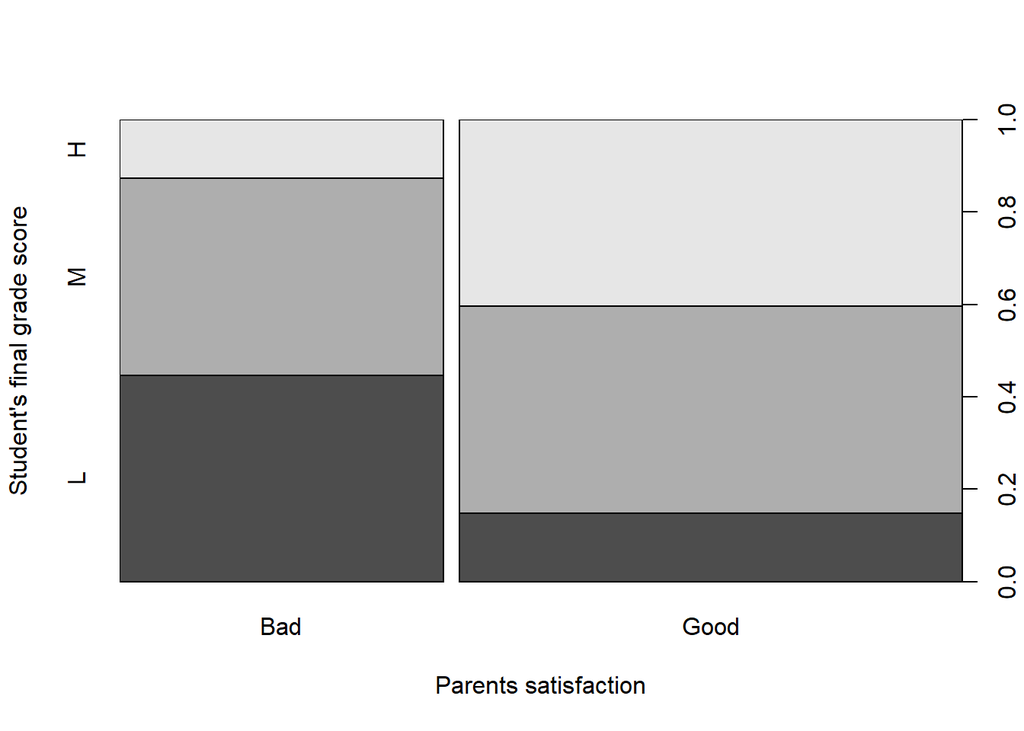

```r
plot(Parent_Sats, final_grade, ylab = "Student's final grade score", xlab = "Parents satisfaction")
```

The plot showed that larger portion of students from parents who have good satisfaction scored better grade than students whose parents have bad satisfaction.

### Test for group difference

*Is there difference in studetns’ hand raising as a function of their sex?*

Examine the assumptions for parametric test to decide the statistical test to be used. In this regard, independence of observations is automatic as the two observations are completely independent (male and female).

Do box plot to examine the equivalence of variance between the two groups

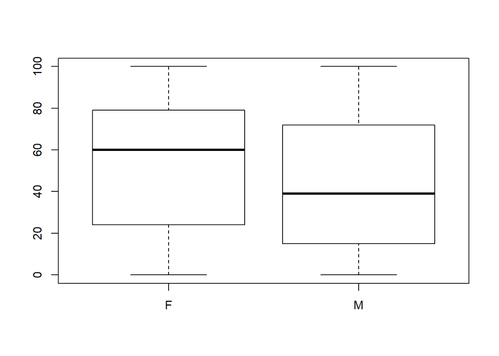

```r
boxplot(stud_performance_data$raisedhands~sex)
```

The boxplot indicates that the variances of the two groups are almost the same. This can also be verified usng Levene’s Test

```r
leveneTest(stud_performance_data$raisedhands~sex)
```

```
## Levene's Test for Homogeneity of Variance (center = median)
##        Df F value Pr(>F)
## group   1  0.9706  0.325
##       478
```

Levene’s Test confirmed that the difference in variance the two groups is not significant.

Now conduct t-test to verify/refute the hypothesis

```r
t.test(stud_performance_data$raisedhands~stud_performance_data$sex, mu=0, alt="two.sided", conf=0.95, var.eq=T, paired=F)
```

```
##
##  Two Sample t-test
##
## data:  stud_performance_data$raisedhands by stud_performance_data$sex
## t = 3.3165, df = 478, p-value = 0.0009809
## alternative hypothesis: true difference in means is not equal to 0
## 95 percent confidence interval:
##   3.904502 15.257278
## sample estimates:
## mean in group 1 mean in group 2
##        52.86286        43.28197
```

To include SD statistics in the report calculate it

```r
sd(stud_performance_data$raisedhands[sex=="F"])
```

```
## [1] 30.21805
```

```r
sd(stud_performance_data$raisedhands[sex=="M"])
```

```
## [1] 30.60217
```

### Correlation

*Is there a statistical significant relationship between announcement view and participation in discussion?*

In the exploratory analysis part it was confirmed that the distribution of both announcement view and discussion were not normal.

So, Check the the transform of the scores if it helps for normality

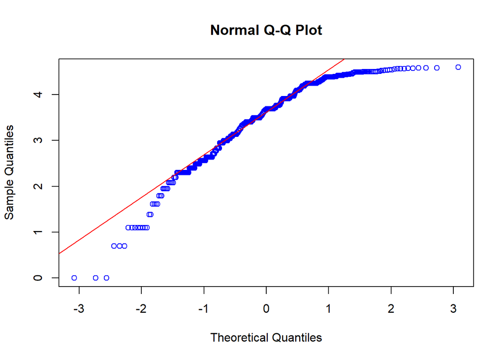

```r
log_Discussion<-log(stud_performance_data$Discussion)
qqnorm(log_Discussion, col='blue')
qqline(log_Discussion, col ="red")
```

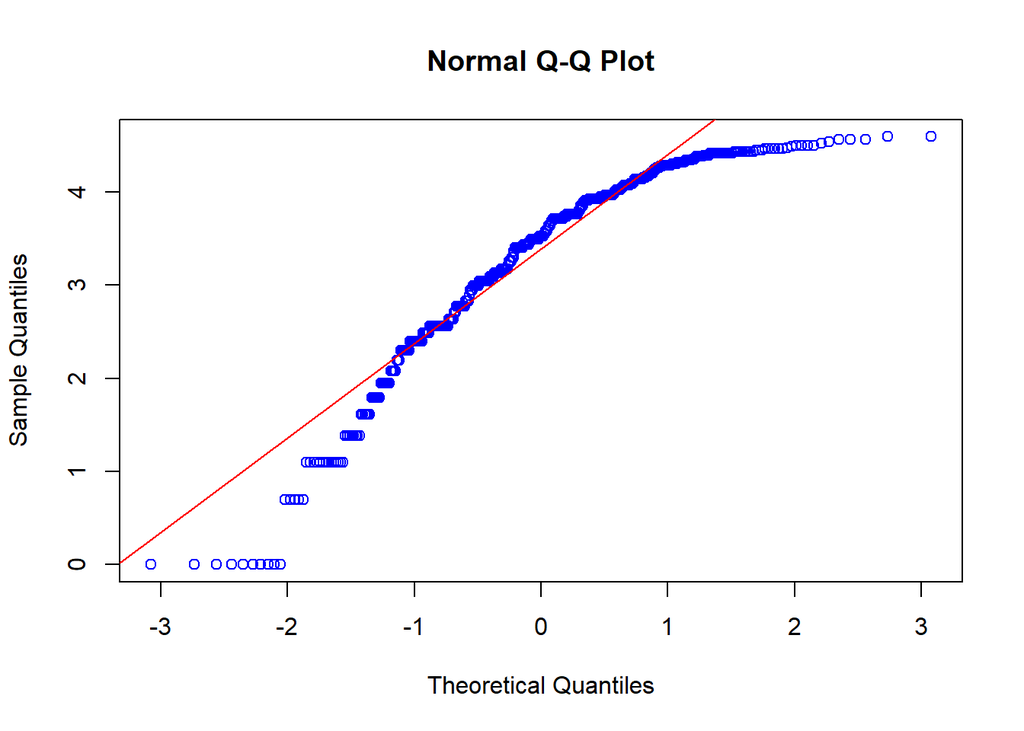

```r
log_AnnouncementsView<-log(stud_performance_data$AnnouncementsView + 1)
qqnorm(log_AnnouncementsView, col='blue')
qqline(log_AnnouncementsView, col ="red")
```

Still the transformation of the scores in both variables didn’t help them for normality

Plot to examine monotonic relationship between the two variables to use Kendall’s tau.

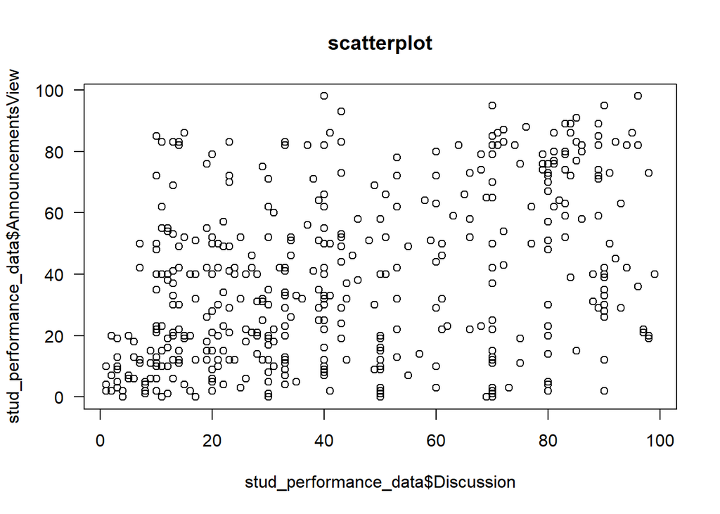

```r
plot(stud_performance_data$Discussion, stud_performance_data$AnnouncementsView, main="scatterplot", las=1)
```

The plot shows that it fulfilled the assumption of monotonic relationship

Now conduct correlation test

```r
cor.test(stud_performance_data$Discussion, stud_performance_data$AnnouncementsView, method="kendall")
```

```
##
##  Kendall's rank correlation tau
##
## data:  stud_performance_data$Discussion and stud_performance_data$AnnouncementsView
## z = 9.1773, p-value < 2.2e-16
## alternative hypothesis: true tau is not equal to 0
## sample estimates:
##       tau
## 0.2851579
```

A Kendall’s tau coefficient was computed to assess the relationship between the announcement view and students’ participation in discussion. The result depicted that there is a significant correlation between the two variables [r (478)= 0.285, p <.0001].

### Regression Analysis

- Do resource visiting and announcement viewing significantly predict students hand raising behavior?

The relationship among the variables used in the hypothesis is studied using plot matrix (used to check the linearity of relationship between IVs with DV)

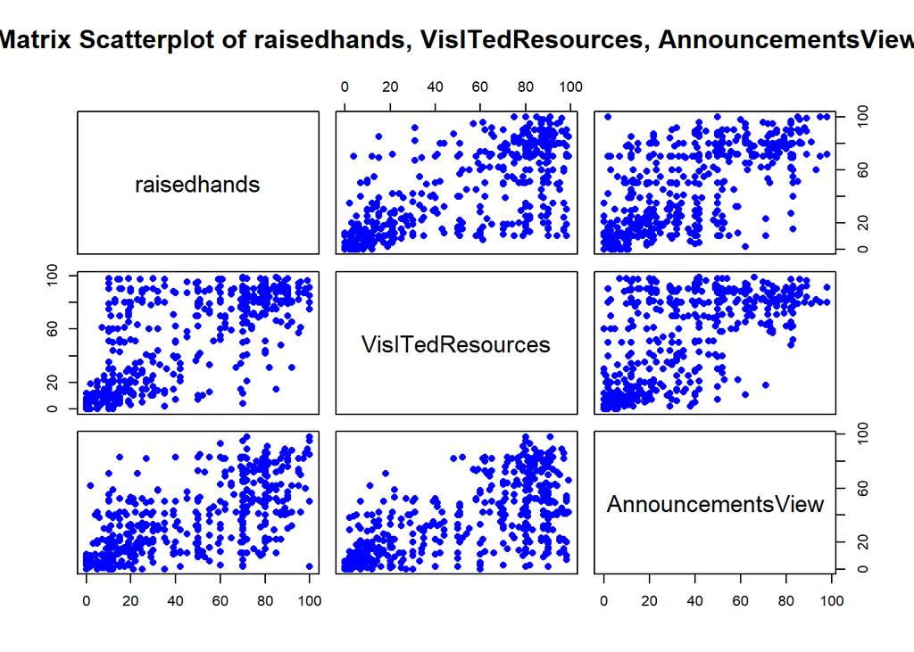

```r
plot(stud_performance_data[5:7], pch=16, col="blue", main="Matrix Scatterplot of raisedhands, VisITedResources, AnnouncementsView")
```

As can be seen from the plot matrix the assumption of linear relationship between IVs and DV is fulfilled.

Explore the jointed effect of visiting resource and announcement vewing on handraising using coplot function.

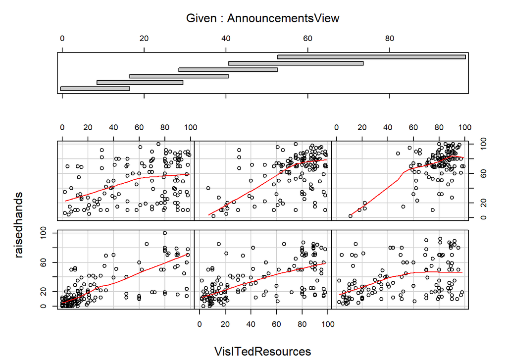

```r
coplot(raisedhands~VisITedResources|AnnouncementsView, panel = panel.smooth, stud_performance_data)
```

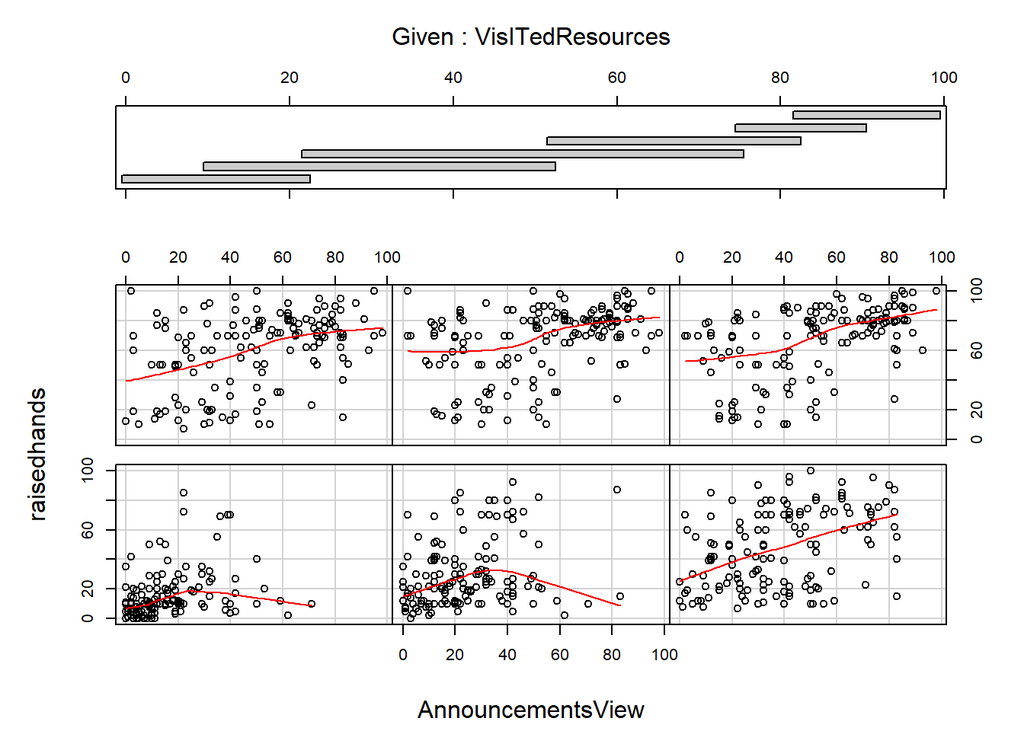

```r
coplot(raisedhands ~AnnouncementsView|VisITedResources, panel = panel.smooth, stud_performance_data)
```

Check for multicollinearity using correlation matrix of independent variables. Just for the sake of more understanding it is possible to include also the dependent variable.

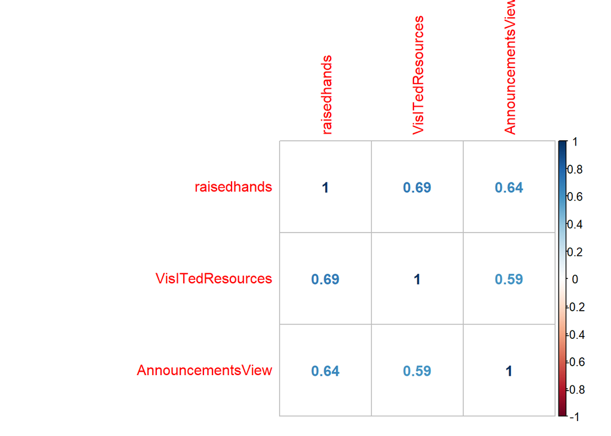

```r
library(corrplot)
check_cor = cor(stud_performance_data[5:7])
corrplot(check_cor, method = "number")
```

The correlation matrix table depicted that the magnitude of the correlation coefficients between independent variables are below the cutoff (.80). There for multicollinearity is not an issue here.

Now, construct a linear model and residual diagnosis

Fit the first model and conduct the corresponding residual diagnosis

```r
lm1<-lm(raisedhands~VisITedResources + AnnouncementsView, data=stud_performance_data)
summary(lm1)
```

```
##
## Call:
## lm(formula = raisedhands ~ VisITedResources + AnnouncementsView,
##     data = stud_performance_data)
##
## Residuals:
##     Min      1Q  Median      3Q     Max
## -57.254 -11.179   0.393  12.918  62.537
##
## Coefficients:
##                   Estimate Std. Error t value Pr(>|t|)
## (Intercept)        6.63719    1.87488   3.540 0.000439 ***
## VisITedResources   0.44433    0.03506  12.673  < 2e-16 ***
## AnnouncementsView  0.41641    0.04358   9.554  < 2e-16 ***
## ---
## Signif. codes:  0 '***' 0.001 '**' 0.01 '*' 0.05 '.' 0.1 ' ' 1
##
## Residual standard error: 20.41 on 477 degrees of freedom
## Multiple R-squared:  0.5621, Adjusted R-squared:  0.5602
## F-statistic: 306.1 on 2 and 477 DF,  p-value: < 2.2e-16
```

The p value indicates that both VisITedResources and AnnouncementsView significantly contribute to the model and hence both of them should be keept.

Diagnose the distribution of the residuals in the model.

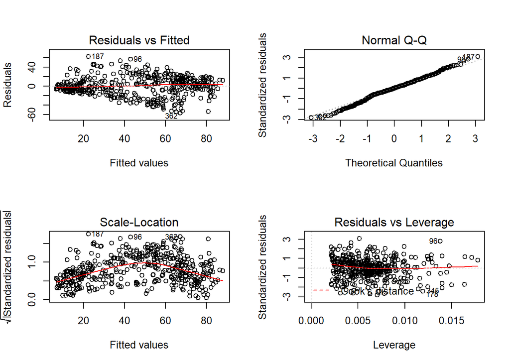

```r
par(mfrow=c(2, 2))
plot(lm1)
```

From the plot it is possible to observe that residuals are randomly distributed around regression line. Besides, from the Q-Q plot, it seems that residuals follow normal distribution. So, residuals in the this model have passed the test of Normality.

The scale-location plot is a bit bent from the horizonal ideal line and but still it would approximatley indicate that residuals have uniform variance across the range.

Now, fit the second model where both predictors and their interaction together are considered.

```r
lm2<-lm(raisedhands~VisITedResources*AnnouncementsView, data=stud_performance_data)
summary(lm2)
```

```
##
## Call:
## lm(formula = raisedhands ~ VisITedResources * AnnouncementsView,
##     data = stud_performance_data)
##
## Residuals:
##     Min      1Q  Median      3Q     Max
## -57.386 -11.488  -0.135  12.794  62.720
##
## Coefficients:
##                                    Estimate Std. Error t value Pr(>|t|)
## (Intercept)                        7.741111   2.690976   2.877  0.00420
## VisITedResources                   0.423887   0.050066   8.467 3.16e-16
## AnnouncementsView                  0.359233   0.109016   3.295  0.00106
## VisITedResources:AnnouncementsView 0.000840   0.001468   0.572  0.56741
##
## (Intercept)                        **
## VisITedResources                   ***
## AnnouncementsView                  **
## VisITedResources:AnnouncementsView
## ---
## Signif. codes:  0 '***' 0.001 '**' 0.01 '*' 0.05 '.' 0.1 ' ' 1
##
## Residual standard error: 20.43 on 476 degrees of freedom
## Multiple R-squared:  0.5624, Adjusted R-squared:  0.5596
## F-statistic: 203.9 on 3 and 476 DF,  p-value: < 2.2e-16
```

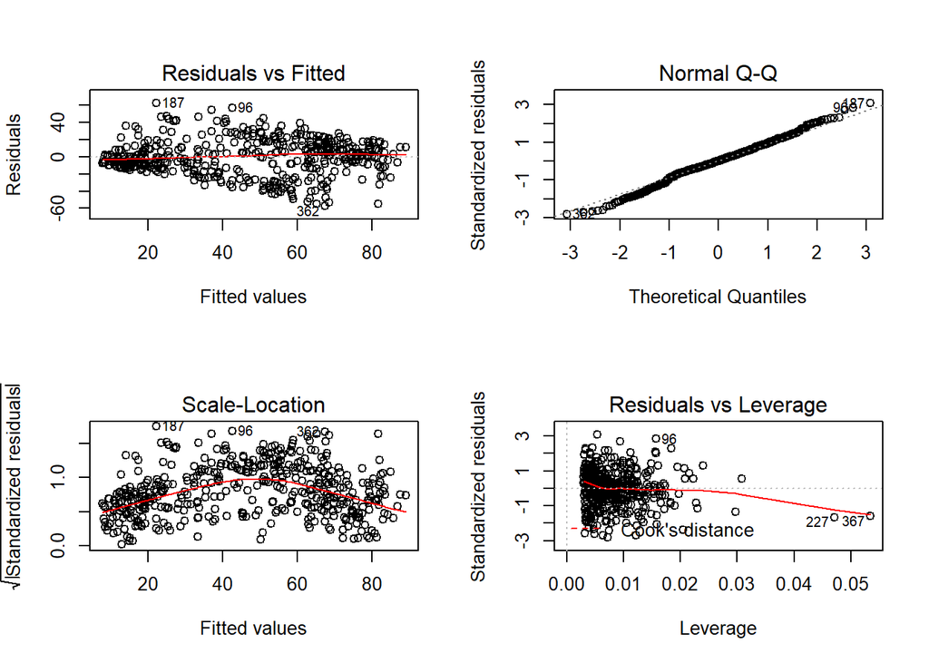

```r
par(mfrow=c(2, 2))
plot(lm2)
```

In this model, compared with model 1 above, the F-Statistic fall down from 306.1 to 203.9. However, no substantial change was seen in residual standard error and adjusted R-square value.

Now, take only interaction between the two predictors and fit as the third model

```r
lm3<-lm(raisedhands~VisITedResources:AnnouncementsView, data=stud_performance_data)
summary(lm3)
```

```
##
## Call:
## lm(formula = raisedhands ~ VisITedResources:AnnouncementsView,
##     data = stud_performance_data)
##
## Residuals:
##     Min      1Q  Median      3Q     Max
## -61.828 -16.113  -3.039  13.605  74.693
##
## Coefficients:
##                                     Estimate Std. Error t value Pr(>|t|)
## (Intercept)                        2.390e+01  1.453e+00   16.45   <2e-16
## VisITedResources:AnnouncementsView 8.798e-03  4.059e-04   21.67   <2e-16
##
## (Intercept)                        ***
## VisITedResources:AnnouncementsView ***
## ---
## Signif. codes:  0 '***' 0.001 '**' 0.01 '*' 0.05 '.' 0.1 ' ' 1
##
## Residual standard error: 21.88 on 478 degrees of freedom
## Multiple R-squared:  0.4956, Adjusted R-squared:  0.4946
## F-statistic: 469.7 on 1 and 478 DF,  p-value: < 2.2e-16
```

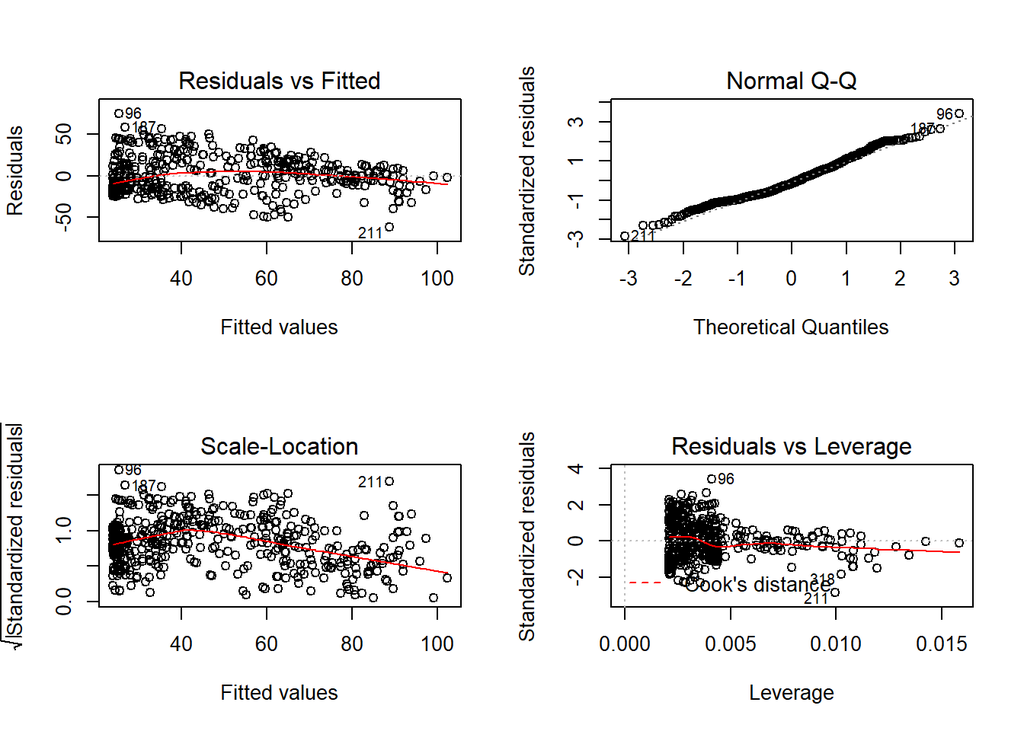

```r
par(mfrow=c(2, 2))
plot(lm3)
```

Compared to the first model, in this model adjusted R-squared value gets down while residual standard error almost stayed the same. On the other hand, the F-statistic get improved from 306.1 to 469.7 almost for the same degree of freedom.

Now, let’s fix the confidence intervals for parameters.

```r
confint(lm1, level = 0.95)
```

```
##                       2.5 %     97.5 %
## (Intercept)       2.9531474 10.3212263
## VisITedResources  0.3754325  0.5132187
## AnnouncementsView 0.3307687  0.5020486
```

```r
confint(lm2, level = 0.95)
```

```
##                                           2.5 %       97.5 %
## (Intercept)                         2.453449404 13.028772138
## VisITedResources                    0.325508381  0.522265018
## AnnouncementsView                   0.145020815  0.573445233
## VisITedResources:AnnouncementsView -0.002044292  0.003724304
```

```r
confint(lm3, level = 0.95)
```

```
##                                           2.5 %       97.5 %
## (Intercept)                        21.044274119 26.754756871
## VisITedResources:AnnouncementsView  0.008000253  0.009595484
```

**Model selection**  
compare the models using broom::glance()

```r
glance(lm1)
```

```
##   r.squared adj.r.squared    sigma statistic      p.value df    logLik
## 1 0.5620764     0.5602403 20.41105  306.1156 2.975109e-86  3 -2127.303
##        AIC    BIC deviance df.residual
## 1 4262.605 4279.3 198723.5         477
```

```r
glance(lm2)
```

```
##   r.squared adj.r.squared    sigma statistic      p.value df    logLik
## 1 0.5623775     0.5596194 20.42546  203.8985 4.998754e-85  4 -2127.137
##        AIC      BIC deviance df.residual
## 1 4264.275 4285.144 198586.8         476
```

```r
glance(lm3)
```

```
##   r.squared adj.r.squared    sigma statistic      p.value df    logLik
## 1 0.4956469     0.4945917 21.88159  469.7486 4.646176e-73  2 -2161.198
##        AIC      BIC deviance df.residual
## 1 4328.396 4340.918 228868.2         478
```

To confirm model selection annova function can be used

```r
anova(lm1, lm2)
```

```
## Analysis of Variance Table
##
## Model 1: raisedhands ~ VisITedResources + AnnouncementsView
## Model 2: raisedhands ~ VisITedResources * AnnouncementsView
##   Res.Df    RSS Df Sum of Sq      F Pr(>F)
## 1    477 198723
## 2    476 198587  1    136.63 0.3275 0.5674
```

```r
anova(lm1, lm3)
```

```
## Analysis of Variance Table
##
## Model 1: raisedhands ~ VisITedResources + AnnouncementsView
## Model 2: raisedhands ~ VisITedResources:AnnouncementsView
##   Res.Df    RSS Df Sum of Sq      F    Pr(>F)
## 1    477 198723
## 2    478 228868 -1    -30145 72.357 2.334e-16 ***
## ---
## Signif. codes:  0 '***' 0.001 '**' 0.01 '*' 0.05 '.' 0.1 ' ' 1
```

F value indicated that there is significant difference between the first and the third model in favor of the first. Threfore, anova analysis aslo comfirmed that the first model is the winner.

Normal distribution of resuduals in the winner model can be confirmed again as follows

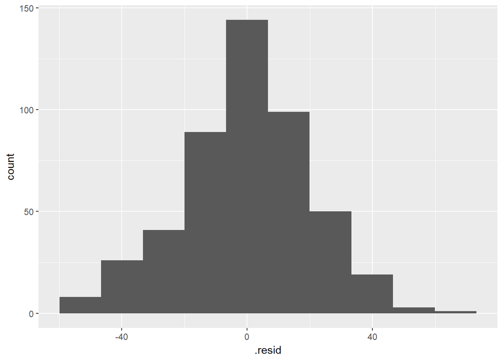

```r
stud_performance_data %>%
  augment(lm(raisedhands~VisITedResources + AnnouncementsView, data = .), .) %>%
  ggplot() +
  aes(.resid) +
  geom_histogram(bins = 10)
```

The residuals of the selected model are approximatelly normally distributed!

```r
stud_performance_data %>%
  augment(lm(raisedhands ~ VisITedResources*AnnouncementsView, data = .), .) %>%
  pull(.resid) %>%
  shapiro.test(.)
```

```
##
##  Shapiro-Wilk normality test
##
## data:  .
## W = 0.99443, p-value = 0.07819
```

Now, report the results of multiple regression anaysis in table form.

```r
library(stargazer)
library(knitr)
```

```r
Models_table <-
  stargazer(lm1,
            lm2,
            lm3,
            coef = list(lm1$standardized.coefficients,
                        lm2$standardized.coefficients,
                        lm3$standardized.coefficients),
            title = "Model comparison",
            dep.var.labels = "Hand Raising",
            align = TRUE,
            ci = TRUE,
            df = TRUE,
            digits = 2,
            type = "html")
```

```r
kable(Models_table)
```

[output not shown]

**Model comparison**

|  | *Dependent variable:* |  |  |
| --- | --- | --- | --- |
|  | Hand Raising |  |  |
|  | (1) | (2) | (3) |
| VisITedResources | 0.44*** | 0.42*** |  |
|  | (0.38, 0.51) | (0.33, 0.52) |  |
| AnnouncementsView | 0.42*** | 0.36*** |  |
|  | (0.33, 0.50) | (0.15, 0.57) |  |
| VisITedResources:AnnouncementsView |  | 0.001 | 0.01*** |
|  |  | (-0.002, 0.004) | (0.01, 0.01) |
| Constant | 6.64*** | 7.74*** | 23.90*** |
|  | (2.96, 10.31) | (2.47, 13.02) | (21.05, 26.75) |
| Observations | 480 | 480 | 480 |
| R<sup>2</sup> | 0.56 | 0.56 | 0.50 |
| Adjusted R<sup>2</sup> | 0.56 | 0.56 | 0.49 |
| Residual Std. Error | 20.41 (df = 477) | 20.43 (df = 476) | 21.88 (df = 478) |
| F Statistic | 306.12*** (df = 2; 477) | 203.90*** (df = 3; 476) | 469.75*** (df = 1; 478) |
| *Note:* | p<0.1; p<0.05; p<0.01 |  |  |

# Also add standardized coefficients

Transform the non-standardized values using the lm.beta package

```r
library(lm.beta)
```

Create standardized versions from all objects

```r
lm1_std <- lm.beta(lm1)
lm2_std <- lm.beta(lm2)
lm3_std <- lm.beta(lm3)
```

explicitly tell stargazer which coefficients we want to see

```r
results_table<-
  stargazer(lm1_std,
            lm2_std,
            lm3_std,
            coef = list(lm1_std$standardized.coefficients,
                        lm2_std$standardized.coefficients,
                        lm3_std$standardized.coefficients),

            title = "Model comparison",
            dep.var.labels = "Raising Hand",
            align = TRUE,
            ci = TRUE,
            df = TRUE,
            digits = 2,
            type = "html")
```

```r
kable(results_table)
```

[output not shown]

**Model comparison**

|  | *Dependent variable:* |  |  |
| --- | --- | --- | --- |
|  | Raising Hand |  |  |
|  | (1) | (2) | (3) |
| VisITedResources | 0.48*** | 0.46*** |  |
|  | (0.41, 0.55) | (0.36, 0.55) |  |
| AnnouncementsView | 0.36*** | 0.31*** |  |
|  | (0.27, 0.45) | (0.10, 0.52) |  |
| VisITedResources:AnnouncementsView |  | 0.07*** | 0.70*** |
|  |  | (0.06, 0.07) | (0.70, 0.70) |
| Constant | 0.00 | 0.00 | 0.00 |
|  | (-3.67, 3.67) | (-5.27, 5.27) | (-2.85, 2.85) |
| Observations | 480 | 480 | 480 |
| R<sup>2</sup> | 0.56 | 0.56 | 0.50 |
| Adjusted R<sup>2</sup> | 0.56 | 0.56 | 0.49 |
| Residual Std. Error | 20.41 (df = 477) | 20.43 (df = 476) | 21.88 (df = 478) |
| F Statistic | 306.12*** (df = 2; 477) | 203.90*** (df = 3; 476) | 469.75*** (df = 1; 478) |
| *Note:* | p<0.1; p<0.05; p<0.01 |  |  |

A multiple linear regression was calculated to predict hand raising based on visiting resources and viewing announcement. A significant regression equation was found (F (2, 477) = 306.12, p< .0001), with an R2 =0.56. Participants’ predicted hand raising is equal to 6.64 + 0.44 (visiting resource) + 0.42 (viewing announcement). Both resource visit and announcement view were significant predictors of hand raising frequency.

## Conclusion

The main goal of this project was to examine the effect of applying Leading-Edge Technology in Education on students academic behavior. To achieve this goal different research questions were formulated and relevant statistical tests were employed. Base on the results it was concluded that:

3.There is an association between announcement view and participation in discussion.

4.Students’ hand raising is better predicted by visiting resources and announcement viewing.